# JC virus propagation is potentiated by glial replication and accelerated by demyelination-associated glial proliferation

Nguyen PT Huynh

2021-03-02

Abstract

Script to generate figures and differential analysis results for Cui et al.

# Packages and Data Input

```r
# Read in libraries
library("DESeq2")
library("RColorBrewer")
library("BiocStyle")
library("knitr")
library("EDASeq")
library("VennDiagram")
library("RUVSeq")
library("ggplot2")
library("enrichR")
library("pheatmap")
library("BiocParallel")
register(MulticoreParam(8))
# color to use for heatmap and pca plots
main_color <- scales::hue_pal()(3)
colors <- RColorBrewer::brewer.pal(8, "Set1")[3:5]
main_pal <- colorRampPalette(c("navy", "red4", "yellow"))(300)
```

```r
# Differential Expression Test
cond <- list(test1=c("JC4", "CTR"), test2=c("JC14", "CTR"), test3=c("JC14", "JC4"))
K <- 2
# Read in data. There should be 3 txt files located under subfolder ./data
countParent <- read.table("./data/countData.txt", sep="\t", header=TRUE, row.names=1)
covParent <- read.table("./data/covData.txt", sep="\t", header=TRUE)
covParent$covariate <- as.character(covParent$covariate)
sampleParent <- read.table("./data/sampleData.txt", sep="\t", header=TRUE, row.names=1)
row.names(sampleParent) <- paste0("X", row.names(sampleParent))
# Filter data to only retain genes that have at least 2 counts in one third of the data set.
athird <- round(dim(countParent)[2]/3)
countParent <- countParent[which(apply(countParent, 1, sum) > (2*athird)), ]
survivingGenes <- dim(countParent)[1]
```

# Differential Expression Analysis with Removal of Unwated Variation

```r
# Interactively run through all test conditions, computes and renders all html
src=lapply(seq_along(cond), function(i) {
  cur_cond=names(cond)[[i]]
  print(cond[[cur_cond]][2])
  print(cond[[cur_cond]][1])
  knit_expand(file="./RuvChild.Rmd", cond1=cond[[cur_cond]][2], cond2=cond[[cur_cond]][1], K=K)
})

knit_res=paste(knit_child(text=unlist(src)), collapse="\n")
```

```r
# Subset data based on treatment and condition pair
cond1="CTR"
cond2="JC4"
```

## Differential Expression Results: JC4 vs CTR

```r
KK="2"
KK <- as.numeric(KK)
suffix <- paste0(cond2, "_vs_", cond1)
dir.create(suffix)
# sampleData clean-up ----------------------------------------------------------
### Only get the row.names (sample) of investigating condition.
sampleData <- sampleParent[c(which(sampleParent$condition==cond1),
                             which(sampleParent$condition==cond2)), ]
### Only get the colnames (covariate) of investigating variances.
sampleData <- sampleData[, which(covParent$take_nottake==1)]
### Relevel condition so that it's TREATMENT vs CONTROL
sampleData$condition <- droplevels(sampleData$condition)
sampleData$condition <- factor(sampleData$condition, levels=c(cond1, cond2))

# countData clean-up -----------------------------------------------------------
countData <- countParent[, row.names(sampleData)]

# covData clean-up -------------------------------------------------------------
covData <- covParent[which(covParent$take_nottake==1),]
```

```r
if (all.equal(colnames(sampleData), as.character(covData$covariate)) != TRUE) {
  error1 <- "Error: Check sampleData and covData. They do not have the same covariate strings."
  print(colnames(sampleData))
  print(covData$covariate)}

if (all.equal(colnames(countData), row.names(sampleData)) != TRUE) {error2 <- "Error: Check countData and sampleData. They do not have the same column names and row names"
  } else {
    # Make DESeq object
    dds <- DESeqDataSetFromMatrix(countData=countData, colData=sampleData, design= ~ condition)
    dds$condition <- factor(dds$condition, levels=c(cond1, cond2))
    dds <- DESeq(dds, parallel=TRUE)
  } #-End else

if(exists("error1")) { print(error1)}
if(exists("error2")) { print(error2)}
```

### DESeq2 First-Pass

DESeq2 was used to perform data normalization and differential expression analysis. This is the first pass to create a set of genes whose expressions were not differentially expressed between 2 investigated groups (adj p-val > 0.75). These genes, refered to as empirical control genes, are then used for downstream RUVseq analysis (Removal of Unwanted Variation).

```r
# Write results of DESeq2 first pass to a text file
res <- results(dds)
res <- lfcShrink(dds, res=res, coef = resultsNames(dds)[2])
res <- as.data.frame(res)
res <- res[order(res$padj), ]
write.table(res, file=paste0(suffix, "/", "FirstPass_deSeq2_", cond2, "_vs_", cond1, ".txt"), quote=FALSE, sep="\t", col.names=NA)
res1 <- res
# Get negative genes for empirical control. In this case we want those genes whose padj values are more than 0.75
empirical <- row.names(res)[which(res$padj > 0.75)]
```

The number of empirical control genes used in this experiment is: 22117

```r
# Write out empirical control genes
filename <- paste0("EmpiricalControlGenes", cond2, "_vs_", cond1, ".txt")
writeLines(empirical, sep="\n", con=filename)

# Run RUVSeq (RUVg)
set <- betweenLaneNormalization(as.matrix(countData), which="upper")
setG <- RUVg(set, empirical, k=KK)
```

### DESeq2 Second-Pass with RUVseq

```r
sampleDataW <-cbind(sampleData, setG$W)
ddsW <- DESeqDataSetFromMatrix(countData = countData, colData = sampleDataW, design = ~ condition)
ddsW$condition <- factor(ddsW$condition, levels = c(cond1, cond2))

### compile formula for DESeq2 based on number of K:
      form_string <- ""
      for (w in 1:KK) {
        if (w == KK) {
          form_string <- paste(form_string, "W_", w, sep = "")
        } else {
          form_string <- paste(form_string, "W_", w, " + ", sep = "")
        } # end else
      } # end for

      design(ddsW) <- formula(paste("~", form_string, " + condition", sep = ""))

ddsW <- DESeq(ddsW, parallel = TRUE)
res <- results(ddsW)
coef <- paste0("condition_", cond2, "_vs_", cond1)
res <- lfcShrink(ddsW, res=res, coef = coef)
res.summary <- res
# Write results of DESeq2 second pass to a text file
res <- res[order(res$padj), ]
res <- as.data.frame(res)
write.table(res, file=paste0(suffix, "/", "RUV_deSeq2_", cond2, "_vs_", cond1, ".txt"), quote=FALSE, sep="\t", col.names=NA)
```

```r
# Subset data based on treatment and condition pair
cond1="CTR"
cond2="JC14"
```

## Differential Expression Results: JC14 vs CTR

```r
KK="2"
KK <- as.numeric(KK)
suffix <- paste0(cond2, "_vs_", cond1)
dir.create(suffix)
# sampleData clean-up ----------------------------------------------------------
### Only get the row.names (sample) of investigating condition.
sampleData <- sampleParent[c(which(sampleParent$condition==cond1),
                             which(sampleParent$condition==cond2)), ]
### Only get the colnames (covariate) of investigating variances.
sampleData <- sampleData[, which(covParent$take_nottake==1)]
### Relevel condition so that it's TREATMENT vs CONTROL
sampleData$condition <- droplevels(sampleData$condition)
sampleData$condition <- factor(sampleData$condition, levels=c(cond1, cond2))

# countData clean-up -----------------------------------------------------------
countData <- countParent[, row.names(sampleData)]

# covData clean-up -------------------------------------------------------------
covData <- covParent[which(covParent$take_nottake==1),]
```

```r
if (all.equal(colnames(sampleData), as.character(covData$covariate)) != TRUE) {
  error1 <- "Error: Check sampleData and covData. They do not have the same covariate strings."
  print(colnames(sampleData))
  print(covData$covariate)}

if (all.equal(colnames(countData), row.names(sampleData)) != TRUE) {error2 <- "Error: Check countData and sampleData. They do not have the same column names and row names"
  } else {
    # Make DESeq object
    dds <- DESeqDataSetFromMatrix(countData=countData, colData=sampleData, design= ~ condition)
    dds$condition <- factor(dds$condition, levels=c(cond1, cond2))
    dds <- DESeq(dds, parallel=TRUE)
  } #-End else

if(exists("error1")) { print(error1)}
if(exists("error2")) { print(error2)}
```

### DESeq2 First-Pass

DESeq2 was used to perform data normalization and differential expression analysis. This is the first pass to create a set of genes whose expressions were not differentially expressed between 2 investigated groups (adj p-val > 0.75). These genes, refered to as empirical control genes, are then used for downstream RUVseq analysis (Removal of Unwanted Variation).

```r
# Write results of DESeq2 first pass to a text file
res <- results(dds)
res <- lfcShrink(dds, res=res, coef = resultsNames(dds)[2])
res <- as.data.frame(res)
res <- res[order(res$padj), ]
write.table(res, file=paste0(suffix, "/", "FirstPass_deSeq2_", cond2, "_vs_", cond1, ".txt"), quote=FALSE, sep="\t", col.names=NA)
res1 <- res
# Get negative genes for empirical control. In this case we want those genes whose padj values are more than 0.75
empirical <- row.names(res)[which(res$padj > 0.75)]
```

The number of empirical control genes used in this experiment is: 6932

```r
# Write out empirical control genes
filename <- paste0("EmpiricalControlGenes", cond2, "_vs_", cond1, ".txt")
writeLines(empirical, sep="\n", con=filename)

# Run RUVSeq (RUVg)
set <- betweenLaneNormalization(as.matrix(countData), which="upper")
setG <- RUVg(set, empirical, k=KK)
```

### DESeq2 Second-Pass with RUVseq

```r
sampleDataW <-cbind(sampleData, setG$W)
ddsW <- DESeqDataSetFromMatrix(countData = countData, colData = sampleDataW, design = ~ condition)
ddsW$condition <- factor(ddsW$condition, levels = c(cond1, cond2))

### compile formula for DESeq2 based on number of K:
      form_string <- ""
      for (w in 1:KK) {
        if (w == KK) {
          form_string <- paste(form_string, "W_", w, sep = "")
        } else {
          form_string <- paste(form_string, "W_", w, " + ", sep = "")
        } # end else
      } # end for

      design(ddsW) <- formula(paste("~", form_string, " + condition", sep = ""))

ddsW <- DESeq(ddsW, parallel = TRUE)
res <- results(ddsW)
coef <- paste0("condition_", cond2, "_vs_", cond1)
res <- lfcShrink(ddsW, res=res, coef = coef)
res.summary <- res
# Write results of DESeq2 second pass to a text file
res <- res[order(res$padj), ]
res <- as.data.frame(res)
write.table(res, file=paste0(suffix, "/", "RUV_deSeq2_", cond2, "_vs_", cond1, ".txt"), quote=FALSE, sep="\t", col.names=NA)
```

```r
# Subset data based on treatment and condition pair
cond1="JC4"
cond2="JC14"
```

## Differential Expression Results: JC14 vs JC4

```r
KK="2"
KK <- as.numeric(KK)
suffix <- paste0(cond2, "_vs_", cond1)
dir.create(suffix)
# sampleData clean-up ----------------------------------------------------------
### Only get the row.names (sample) of investigating condition.
sampleData <- sampleParent[c(which(sampleParent$condition==cond1),
                             which(sampleParent$condition==cond2)), ]
### Only get the colnames (covariate) of investigating variances.
sampleData <- sampleData[, which(covParent$take_nottake==1)]
### Relevel condition so that it's TREATMENT vs CONTROL
sampleData$condition <- droplevels(sampleData$condition)
sampleData$condition <- factor(sampleData$condition, levels=c(cond1, cond2))

# countData clean-up -----------------------------------------------------------
countData <- countParent[, row.names(sampleData)]

# covData clean-up -------------------------------------------------------------
covData <- covParent[which(covParent$take_nottake==1),]
```

```r
if (all.equal(colnames(sampleData), as.character(covData$covariate)) != TRUE) {
  error1 <- "Error: Check sampleData and covData. They do not have the same covariate strings."
  print(colnames(sampleData))
  print(covData$covariate)}

if (all.equal(colnames(countData), row.names(sampleData)) != TRUE) {error2 <- "Error: Check countData and sampleData. They do not have the same column names and row names"
  } else {
    # Make DESeq object
    dds <- DESeqDataSetFromMatrix(countData=countData, colData=sampleData, design= ~ condition)
    dds$condition <- factor(dds$condition, levels=c(cond1, cond2))
    dds <- DESeq(dds, parallel=TRUE)
  } #-End else

if(exists("error1")) { print(error1)}
if(exists("error2")) { print(error2)}
```

### DESeq2 First-Pass

DESeq2 was used to perform data normalization and differential expression analysis. This is the first pass to create a set of genes whose expressions were not differentially expressed between 2 investigated groups (adj p-val > 0.75). These genes, refered to as empirical control genes, are then used for downstream RUVseq analysis (Removal of Unwanted Variation).

```r
# Write results of DESeq2 first pass to a text file
res <- results(dds)
res <- lfcShrink(dds, res=res, coef = resultsNames(dds)[2])
res <- as.data.frame(res)
res <- res[order(res$padj), ]
write.table(res, file=paste0(suffix, "/", "FirstPass_deSeq2_", cond2, "_vs_", cond1, ".txt"), quote=FALSE, sep="\t", col.names=NA)
res1 <- res
# Get negative genes for empirical control. In this case we want those genes whose padj values are more than 0.75
empirical <- row.names(res)[which(res$padj > 0.75)]
```

The number of empirical control genes used in this experiment is: 10057

```r
# Write out empirical control genes
filename <- paste0("EmpiricalControlGenes", cond2, "_vs_", cond1, ".txt")
writeLines(empirical, sep="\n", con=filename)

# Run RUVSeq (RUVg)
set <- betweenLaneNormalization(as.matrix(countData), which="upper")
setG <- RUVg(set, empirical, k=KK)
```

### DESeq2 Second-Pass with RUVseq

```r
sampleDataW <-cbind(sampleData, setG$W)
ddsW <- DESeqDataSetFromMatrix(countData = countData, colData = sampleDataW, design = ~ condition)
ddsW$condition <- factor(ddsW$condition, levels = c(cond1, cond2))

### compile formula for DESeq2 based on number of K:
      form_string <- ""
      for (w in 1:KK) {
        if (w == KK) {
          form_string <- paste(form_string, "W_", w, sep = "")
        } else {
          form_string <- paste(form_string, "W_", w, " + ", sep = "")
        } # end else
      } # end for

      design(ddsW) <- formula(paste("~", form_string, " + condition", sep = ""))

ddsW <- DESeq(ddsW, parallel = TRUE)
res <- results(ddsW)
coef <- paste0("condition_", cond2, "_vs_", cond1)
res <- lfcShrink(ddsW, res=res, coef = coef)
res.summary <- res
# Write results of DESeq2 second pass to a text file
res <- res[order(res$padj), ]
res <- as.data.frame(res)
write.table(res, file=paste0(suffix, "/", "RUV_deSeq2_", cond2, "_vs_", cond1, ".txt"), quote=FALSE, sep="\t", col.names=NA)
```

## Venn Diagram Showing the Compostion of Differentially Expressed Genes Across Comparisons

```r
##### How many genes are differentially expressed between conditions
####### Cut-off: |FC| > 0 and padj < 0.01
# Read in differential expression results
files <- list.files("../RUV", "RUV_deSeq2", recursive = TRUE, full.names = TRUE)
dres <- list()
for ( file in files) {
  dres[[file]] <- read.table(file)
}
names(dres) <- gsub(".*RUV_deSeq2_", "", names(dres))
names(dres) <- gsub("\\.txt", "", names(dres))
dres_ordered <- lapply(dres, function(x) x[order(x$padj),])

up <- lapply(dres_ordered, function(x) row.names(x)[which(x$log2FoldChange > 0 & x$padj < 0.01)])
down <- lapply(dres_ordered, function(x) row.names(x)[which(x$log2FoldChange < 0 & x$padj < 0.01)])
dys <- lapply(dres_ordered, function(x) row.names(x)[which(abs(x$log2FoldChange) > 0 & x$padj < 0.01)])
```

Venn diagram of upregulated genes across comparisons

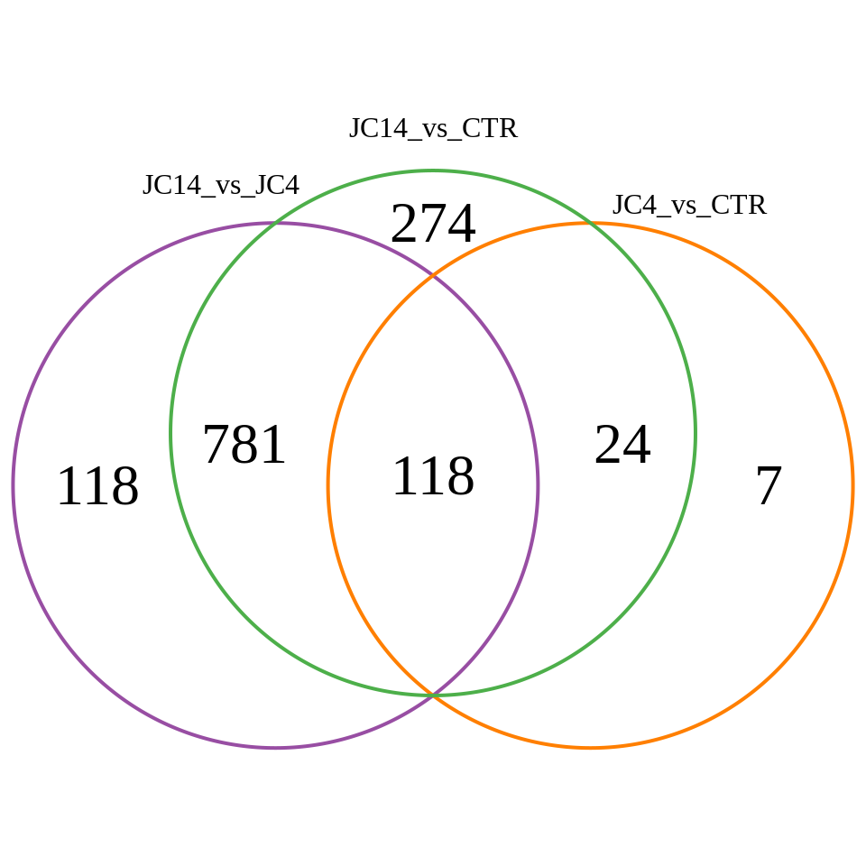

```r
grid.newpage()
vp.up <- venn.diagram(up, fill=NA, filename=NULL, col = colors, cex=2, cat.pos = c(-10,20,0))
grid.draw(vp.up)
```

Venn diagram of downregulated genes across comparisons

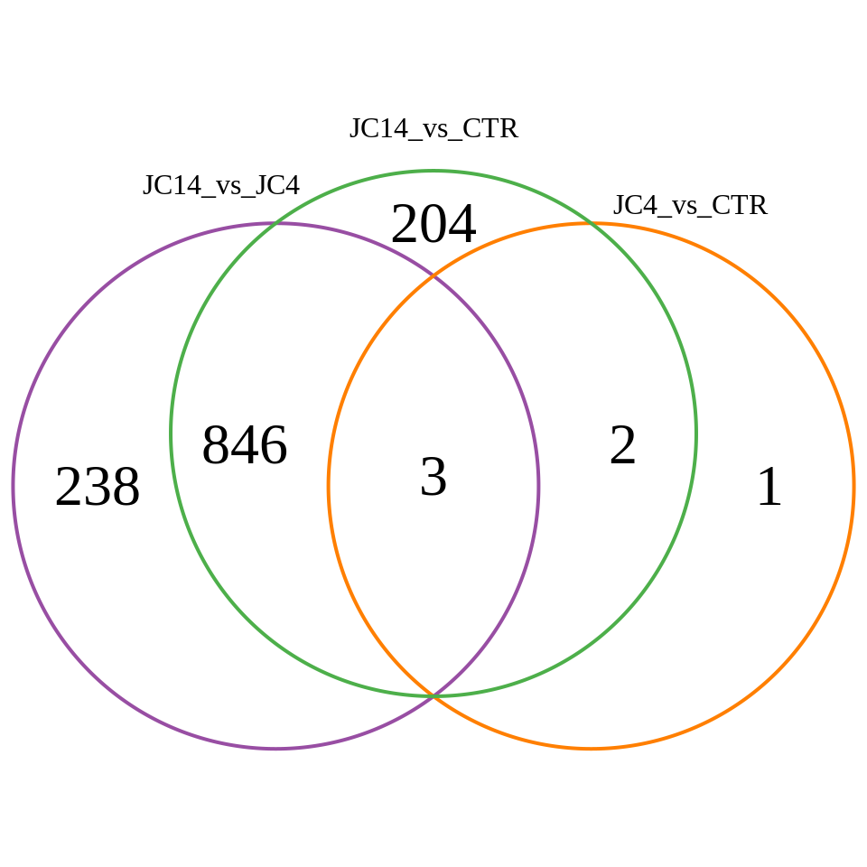

```r
grid.newpage()
vp.down <- venn.diagram(down, fill=NA, filename=NULL, col = colors, cex=2, cat.pos = c(-10,20,0))
grid.draw(vp.down)
```

```r
# Clean up
junk <- list.files(".", "VennDiagram2021", full.names = TRUE)
file.remove(junk)
```

```
## [1] TRUE
```

## Gene Ontology

```r
# Export the union of all the genes
show.f <- function(yourlist) {
                      v <- unlist(yourlist)
                      y <- unique(v)
                      return(y)
                      }
```

### Enriched pathways

```r
# Upregulated and downregulated genes common between conditions
signif.up <- show.f(up)
signif.down <- show.f(down)
```

Number of significantly upregulated genes: 1322  
Number of significantly downregulated genes: 1294

```r
# Submit to enrichR
dbs <- listEnrichrDbs()
enriched <- list()
dbs <- c("GO_Biological_Process_2018")
options(enrichR.base.address="https://amp.pharm.mssm.edu/Enrichr/")
enriched.up <- enrichr(signif.up, dbs)
```

```
## Uploading data to Enrichr... Done.
##   Querying GO_Biological_Process_2018... Done.
## Parsing results... Done.
```

```r
enriched.down <- enrichr(signif.down, dbs)
```

```
## Uploading data to Enrichr... Done.
##   Querying GO_Biological_Process_2018... Done.
## Parsing results... Done.
```

```r
# Function to extract signif GO as a data frame
my_enrichr.f <- function(enrichR_res){
  X <- plyr::ldply(enrichR_res, rbind)
  X <- X[order(X$Adjusted.P.value), ]
  signif_X <- X[which(X$Adjusted.P.value < 0.05),]
  X$Overlap <- gsub("\\/", "_", X$Overlap)
  return(signif_X)
}

# Pathways that are significantly enriched (adjp < 0.05) for each up and down-regulated gene list.
pway.up <- my_enrichr.f(enriched.up)
pway.down <- my_enrichr.f(enriched.down)
```

### Modularity by Community Detection

```r
# Extract the first 10 pathways
#####---------------------------EDGES
options(stringsAsFactors = FALSE)
pway.up <- pway.up[order(pway.up$Adjusted.P.value),]
pway.down <- pway.down[order(pway.down$Adjusted.P.value),]
pway.df <- rbind(pway.up[1:10, c(2,10)], pway.down[1:10,c(2,10)])
df <- data.frame(Source = character(), Target = character())
for (i in 1:nrow(pway.df)) {
  goi <- pway.df$Genes[i]
  goi <- strsplit(goi, ";")[[1]]
  tmp.df <- data.frame(Source = goi, Target = rep(pway.df$Term[i], length(goi)))
  df <- rbind(df, tmp.df)
}
# Remove GO term ID
df$Target <- gsub("\\ \\(GO\\:.*", "", df$Target)
#####---------------------------NODES
df2 <- data.frame(id = c(df$Source, df$Target))
df2$label <- c(rep("Gene", nrow(df)), rep("Pathway", nrow(df)))
row.names(df2) <- NULL
df2 <- df2[!duplicated(df2), ]
df2$early <- rep(0, nrow(df2))
df2$late <- rep(0, nrow(df2))
df2$overall <- rep(0, nrow(df2))
for (i in 1:nrow(df2)) {
  df2$early[i] <- round(dres[[3]][df2$id[i],]$log2FoldChange,1)
  df2$late[i] <- round(dres[[2]][df2$id[i],]$log2FoldChange,1)
  df2$overall[i] <- round(dres[[1]][df2$id[i],]$log2FoldChange,1)
}
df2$direction <- rep(0, nrow(df2))
df2$direction <- ifelse(df2$id %in% signif.up, "up", 0 )
df2$direction <- ifelse(df2$id %in% signif.down, "down", df2$direction)
#####---------------------------This is the input data for Gephi
# write.csv(df,"forGephi_edgeList.csv", row.names = FALSE, quote = FALSE)
# write.csv(df2,"forGephi_nodeList.csv", row.names = FALSE, quote = FALSE)
```

## PCA

### Convert post-RUVseq Counts to TPM for PCA plot

```r
# RUVg with empirical control genes set as the combination of all genes from all comparison
# Run RUVSeq (RUVg) on all samples
empirical <- c(readLines("EmpiricalControlGenesJC14_vs_CTR.txt"),
               readLines("EmpiricalControlGenesJC14_vs_JC4.txt"),
               readLines("EmpiricalControlGenesJC4_vs_CTR.txt"))
empirical <- unique(empirical)
countData <- read.table("./data/countData.txt")
colnames(countData) <- c("Set1_D00","Set1_D04","Set1_D14","Set2_D00","Set2_D04","Set2_D14","Set3_D00","Set3_D04","Set3_D14")
set <- betweenLaneNormalization(as.matrix(countData), which="upper")
setG <- RUVg(set, empirical, k=2)
# Corrected counts
rawCounts <- setG$normalizedCounts
# Import length info
gl <- read.table("./data/gene_lengths.txt", row.names=1, header=T)
gl <- gl[order(row.names(gl)),, drop=FALSE ]
rawCounts <- rawCounts[order(row.names(rawCounts)),]
tpmRUV <- data.frame(row.names=row.names(rawCounts))

for (i in 1:9) {
  geneLength <- merge(rawCounts[,i, drop=FALSE], gl, by="row.names")
  colnames(geneLength) <- c("Gene", "Expression", "Length")
  # Calculate TPM
  geneLength$RPK <- (geneLength$Expression/geneLength$Length)
  scalingBy <- sum(geneLength$RPK)/1000000
  geneLength$TPM <- geneLength$RPK/scalingBy

  # Make data frame to export
  tpmRUV[, i] <- geneLength$TPM
}
colnames(tpmRUV) <- colnames(rawCounts)
```

### PCA Plot

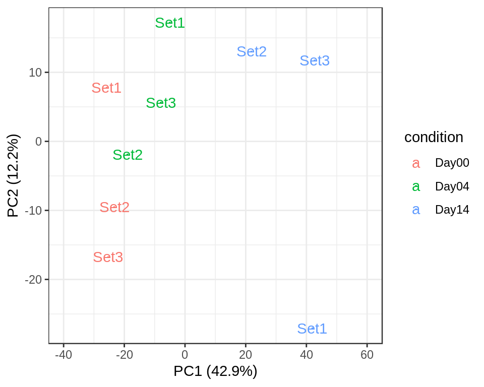

```r
pca <- prcomp(t(log2(tpmRUV+1)))
pcaCoord <- pca$x

eigs <- pca$sdev^2
percentage <- c(eigs[1]/sum(eigs), eigs[2]/sum(eigs))
percentage <-  round(percentage*100, 1)
percentage <- paste0("(", percentage, "%)")
  pcaCoord <- as.data.frame(pcaCoord)
  pcaCoord$condition <- as.factor(rep(c("Day00", "Day04", "Day14"),3))
  p <- ggplot(pcaCoord, aes(PC1, PC2, color=condition)) + geom_point(size = 0) + theme_bw()
  p <- p + geom_text(aes(PC1, PC2, label=gsub("_.*", "", row.names(pcaCoord))))
  p <- p + xlab(paste0("PC1 ", percentage[1])) + ylab(paste0("PC2 ", percentage[2])) + xlim(-40,60)
  p
```

## Heatmaps

### Convert Raw Counts to TPM for Heatmaps

```r
# Raw counts
rawCounts <- read.table("./data/countData.txt")
colnames(rawCounts) <- c("Set1_D00","Set1_D04","Set1_D14","Set2_D00","Set2_D04","Set2_D14","Set3_D00","Set3_D04","Set3_D14")
# Import length info
gl <- read.table("./data/gene_lengths.txt", row.names=1, header=T)
gl <- gl[order(row.names(gl)),, drop=FALSE ]
rawCounts <- rawCounts[order(row.names(rawCounts)),]
tpm <- data.frame(row.names=row.names(rawCounts))

for (i in 1:9) {
  geneLength <- merge(rawCounts[,i, drop=FALSE], gl, by="row.names")
  colnames(geneLength) <- c("Gene", "Expression", "Length")
  # Calculate TPM
  geneLength$RPK <- (geneLength$Expression/geneLength$Length)
  scalingBy <- sum(geneLength$RPK)/1000000
  geneLength$TPM <- geneLength$RPK/scalingBy

  # Make data frame to export
  tpm[, i] <- geneLength$TPM
}
colnames(tpm) <- colnames(rawCounts)
```

### Heatmaps of All Dysregulated Genes

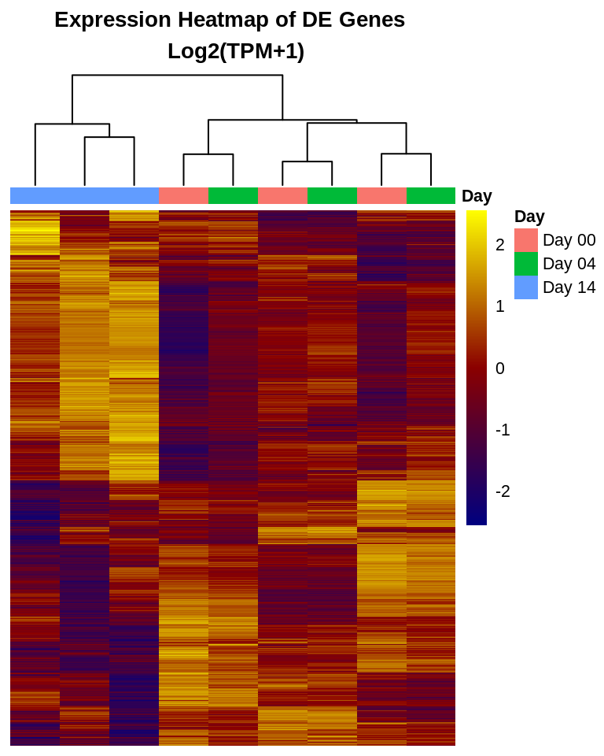

```r
goi <- unique(unlist(dys))
datatoplot <- log2(tpm[goi,]+1)
annotCol <- data.frame(row.names=colnames(datatoplot), Day = rep(c("Day 00", "Day 04", "Day 14"), times = 3))

day_color <- main_color
names(day_color) <- c("Day 00", "Day 04", "Day 14")
annotColor <- list(Day = day_color)
pheatmap(datatoplot, color=main_pal, annotation_col = annotCol, annotation_colors = annotColor,
         show_rownames = FALSE, show_colnames = FALSE, scale="row", cluster_rows = T, cluster_cols = T,
         border_color = "white", treeheight_row = 0, main="Expression Heatmap of DE Genes \n Log2(TPM+1)", fontsize = 8)
```

### Heatmaps of the Top 20 Genes (Ranked by Significance) Identified in Each Module

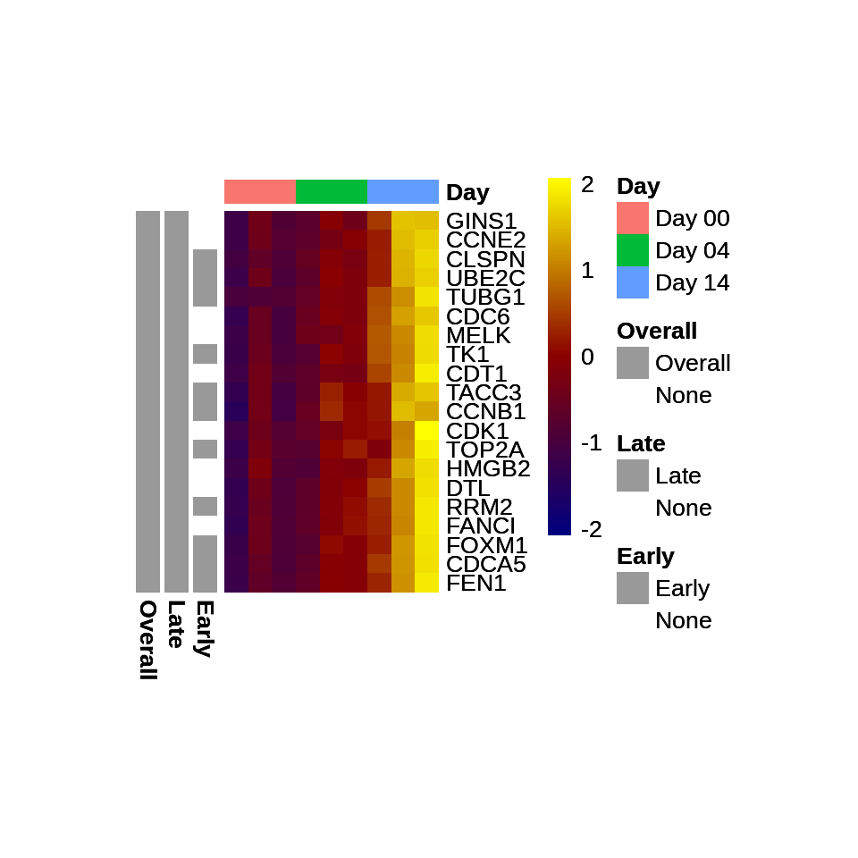

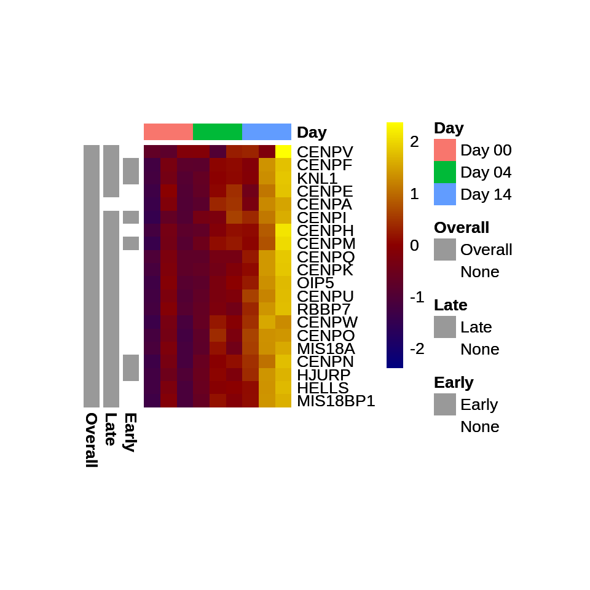

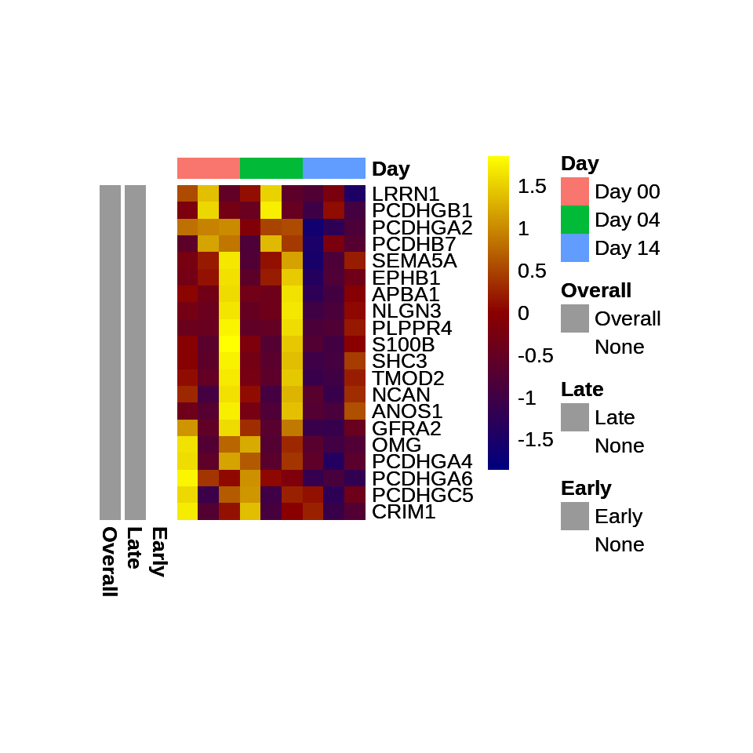

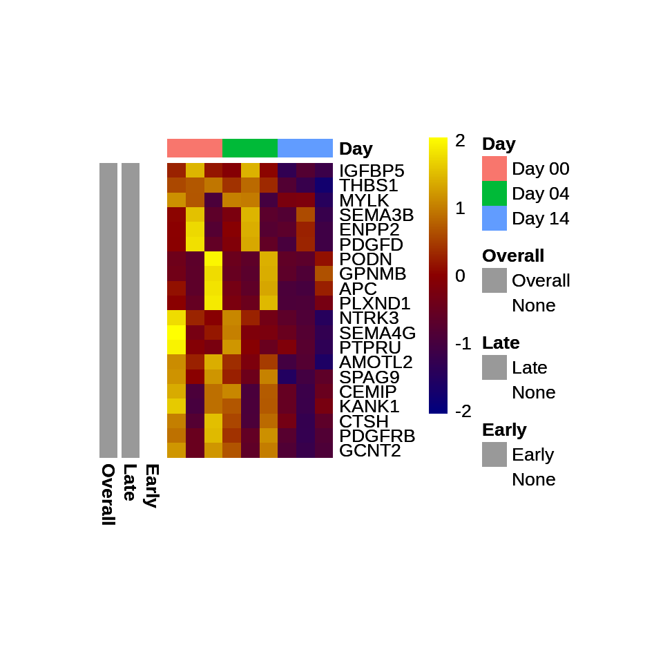

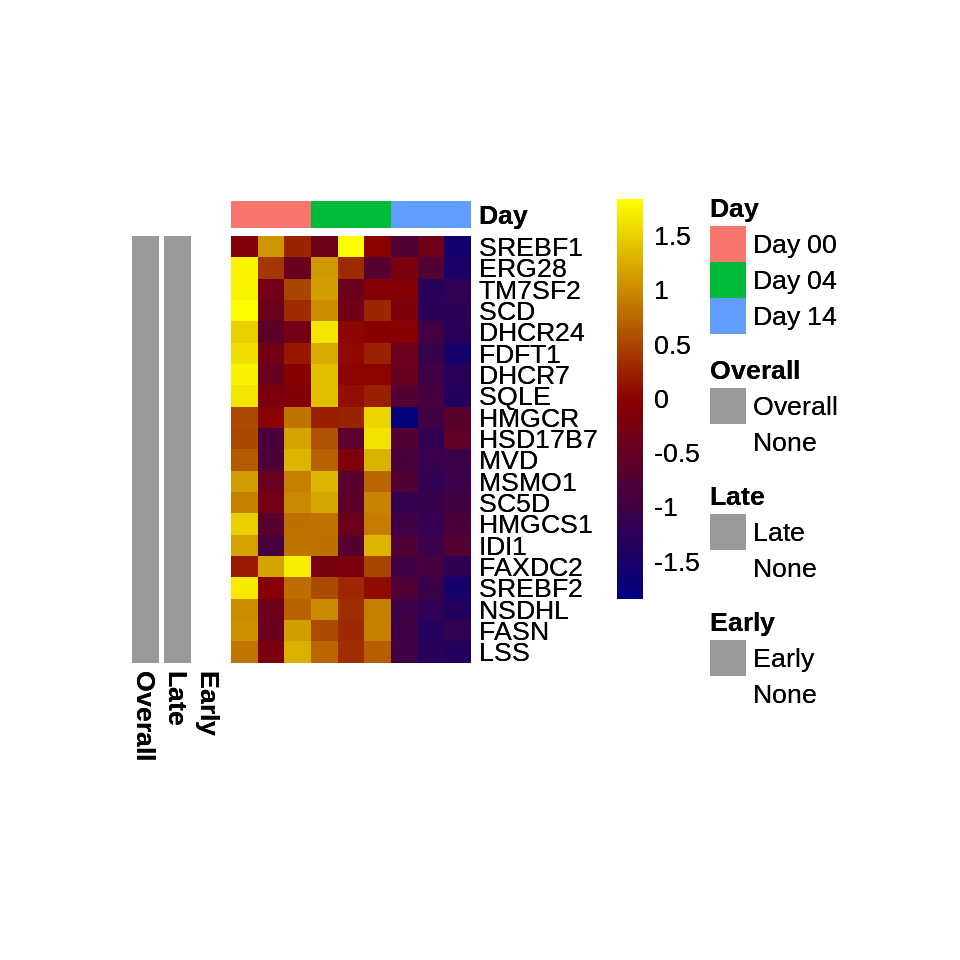

```r
# Modularity Results from Gephi
# Note: Gephy resulted in module number from 0 to 4. We subsequently reported these as M1 to M5 in our manuscript
mod <- read.csv("./data/forCytoscape_nodeList_postGephi.csv", stringsAsFactors = F)
mod <- mod[which(mod$Label == "Gene"), ]
# Get p adjusted values for all genes in mod, just based on the overall changes (i.e. 14 vs CTR)
dys.df <- dres_ordered[[1]][mod$Id, ]
dys.df <- dys.df[order(dys.df$padj),]
dys_ordered <- row.names(dys.df)
# Create annotation for gene names
annotRow2 <- data.frame(row.names = mod$Id)

for (i in 1:nrow(mod)) {
  annotRow2$Early[i] <- ifelse(mod$Id[i] %in% dys[[3]], "Early", "None")
  annotRow2$Late[i] <- ifelse(mod$Id[i] %in% dys[[2]], "Late", "None")
  annotRow2$Overall[i] <- ifelse(mod$Id[i] %in% dys[[1]], "Overall", "None")
}
###########################################
# Heatmap colors
annot_colors <- list(Early=c("grey60", NA), Late=c("grey60", NA), Overall=c("grey60", NA), Day=main_color)
names(annot_colors[[1]]) <- c("Early", "None")
names(annot_colors[[2]]) <- c("Late", "None")
names(annot_colors[[3]]) <- c("Overall", "None")
names(annot_colors[[4]]) <- c("Day 00", "Day 04", "Day 14")
# Rearrange samples
sample.v <- c(1,4,7,2,5,8,3,6,9)
###########################################
for (i in 0:4) {
  goi <- mod$Id[mod$modularity_class == i]
  goi <- dys_ordered[dys_ordered %in% goi][1:20]
  # Top 20 of the dysregulated genes
  datatoplot2 <- tpm[goi,]
  datatoplot2 <- datatoplot2[, sample.v]
  print(pheatmap(as.matrix(datatoplot2), annotation_col =  annotCol, annotation_row = annotRow2[goi,], annotation_colors = annot_colors,cluster_rows = T, cluster_cols = F, color = main_pal, border_color = NA, scale = "row", cellwidth = 10, cellheight = 8, show_rownames = TRUE, show_colnames = FALSE, clustering_method = "complete", treeheight_row = 0))
}
```

### Heatmaps of All Genes Identified in Each Module

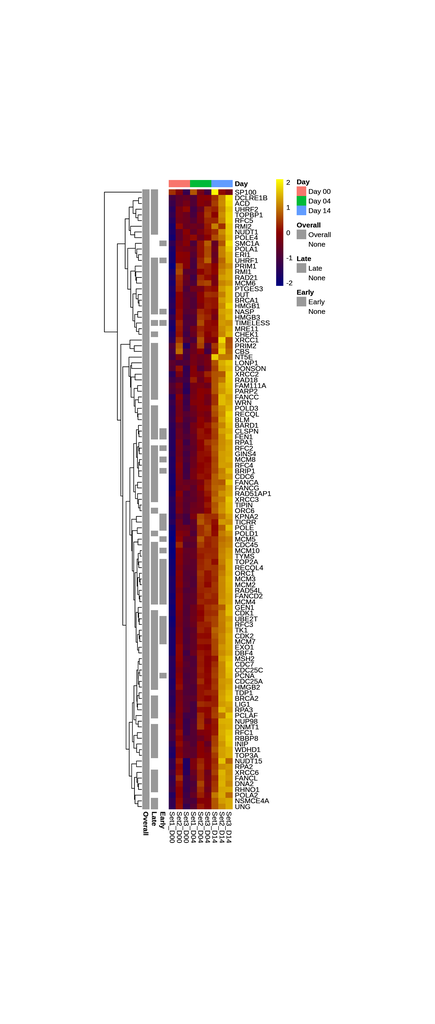

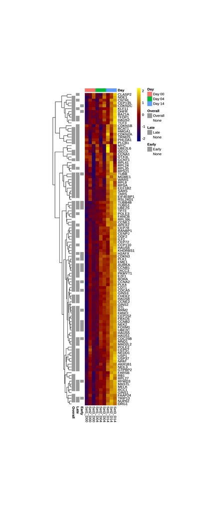

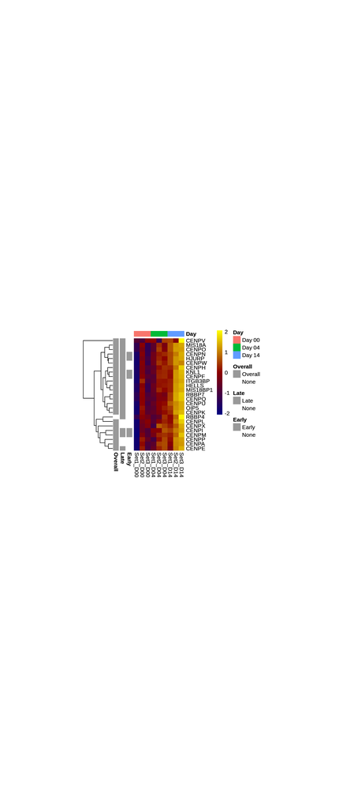

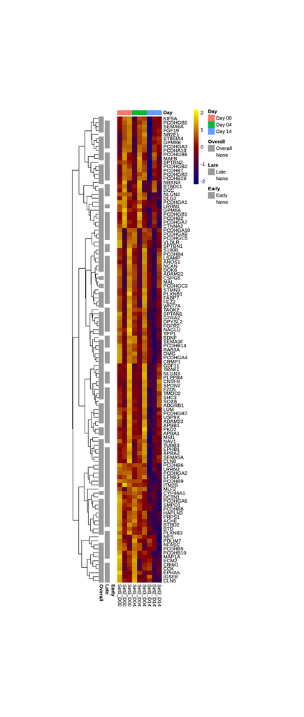

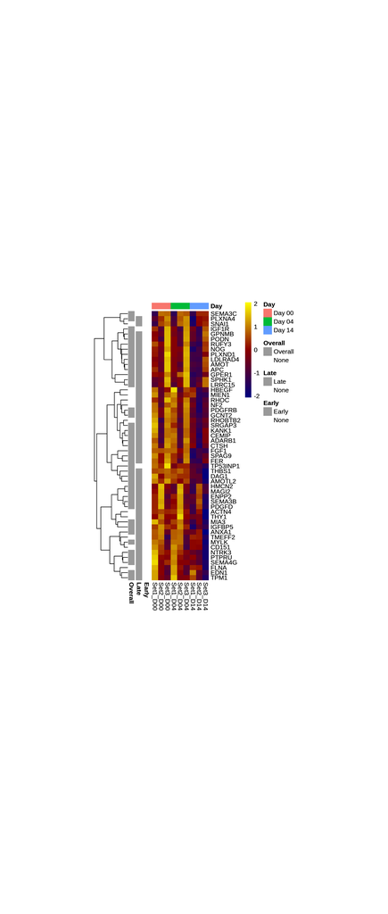

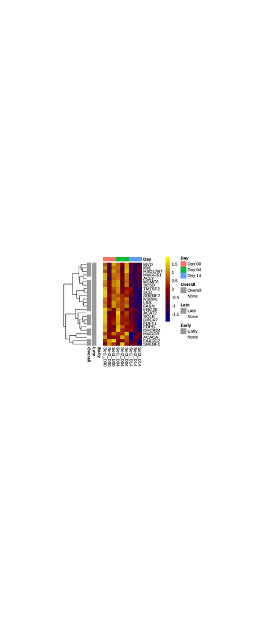

```r
for (i in 0:4) {
  goi <- mod$Id[mod$modularity_class == i]
  datatoplot3 <- log2(tpm[goi,] + 1)
  datatoplot3 <- datatoplot3[, sample.v]
  if (i == 0) {
    # There are many genes for M1, thus we split them into two heatmaps
  print(pheatmap(as.matrix(datatoplot3)[1:109,], annotation_col =  annotCol, annotation_row = annotRow2[goi[1:109],], annotation_colors = annot_colors,cluster_rows = T, cluster_cols = F, color = main_pal, border_color = NA, scale = "row", cellwidth = 10, cellheight = 8))
  print(pheatmap(as.matrix(datatoplot3)[110:219,], annotation_col =  annotCol, annotation_row = annotRow2[goi[110:209],], annotation_colors = annot_colors,cluster_rows = T, cluster_cols = F, color = main_pal, border_color = NA, scale = "row", cellwidth = 10, cellheight = 8))
  } else {
  print(pheatmap(as.matrix(datatoplot3), annotation_col =  annotCol, annotation_row = annotRow2[goi,], annotation_colors = annot_colors,cluster_rows = T, cluster_cols = F, color = main_pal, border_color = NA, scale = "row", cellwidth = 10, cellheight = 8))
  }
}
```